# Лабораторная работа №1

Установка и конфигурация операционной системы на виртуальную машину

Чекмарев Александр Дмитриевич | Группа НПИбд-03-24

Российский университет дружбы народов, Москва, Россия

6 сентября 2025

# Информация

## Докладчик

- Чекмарев Александр Дмитриевич
- Группа НПИбд-03-24
- Российский университет дружбы народов
- https://github.com/nenokixd?tab=repositories

# Вводная часть

## Объект и предмет исследования

- Установка ОС Linux Rocky на VirtualBox

## Цель работы

- Целью данной работы является приобретение практических навыков установки операционной системы на виртуальную машину, настройки минимально необходимых для дальнейшей работы сервисов.

# Ход лаборатороной работы

## Скачивание дистрибутива Rocky v10

- Скачиваем iso-образ Rocky актуальной версии на сайте: https://rockylinux.org/ru-RU/download

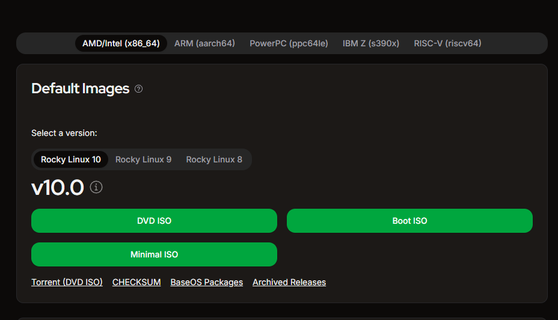

## Настройки в VirtualBox для Rocky

- Выбираем iso образ, название, место
- Выделяем ОЗУ
- Выделяем 40 гб

[figure not shown]

[figure not shown]

[figure not shown]

## Загрузчик операционной системы GRUB

- При запуске нас встречает GRUB, выбираем “install Rocky Linux”

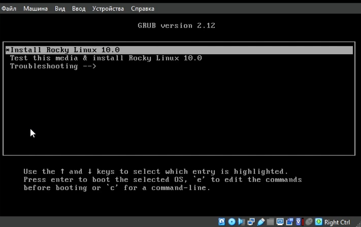

## Меню настроек

- В данном месте у нас находится все что нужно для настройки

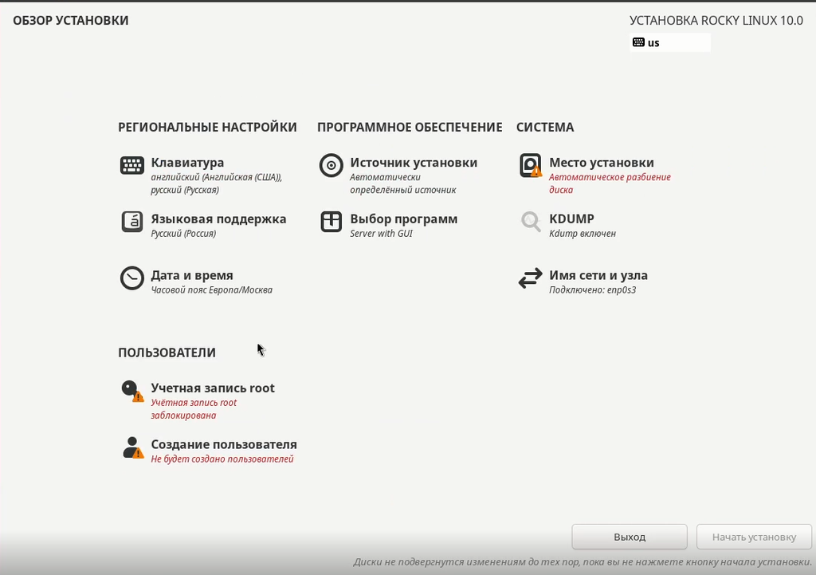

## Язык и жесткий диск

- Выбираем нужный нам язык в пункте Языковая поддержка
- Выбираем жесткий диск в пункте Место установки

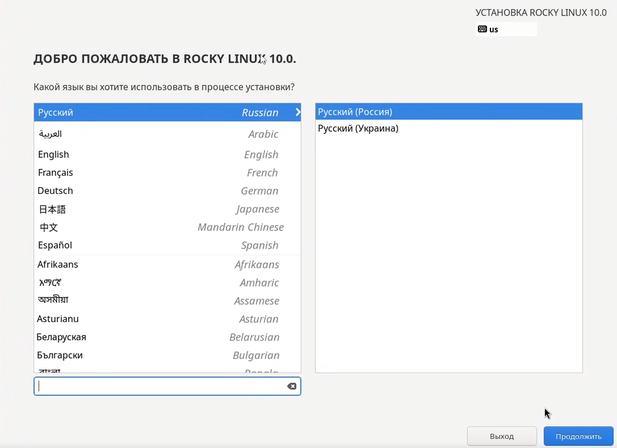

[figure not shown]

## Программное обеспечение, узел и KDUMP

- Переходим в Выбор программ и отмечаем Средства разработки и Server with GUI
- Отключаем KDUMP
- Изменяем имя узла в Имя сети и узла

[figure not shown]

[figure not shown]

[figure not shown]

## Настройка аккаунта пользователя

- Настраиваем аккаунт администратора, выдав ему root права
- Создаем пользователя

[figure not shown]

[figure not shown]

## Конец настроек перед установкой

- Переходим к установке

[figure not shown]

## Подключение образа диска дополнений гостевой OC

- Воспользуемся консольными командами для подключения образа диска дополнений гостевой OC.

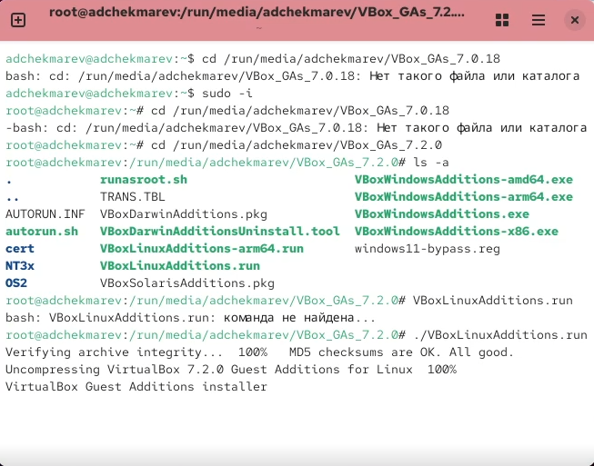

- После загрузки перезагрузим операционную систему на виртуальной машине. На этом все готово

## Вывод:

В процессе работы была установлена и настроена ОС Rocky Linux в среде VirtualBox. Были получены навыки создания и конфигурации виртуальной машины, работы с пользователями.